# Practica4

Ejemplo con los datos islands (viene con R)

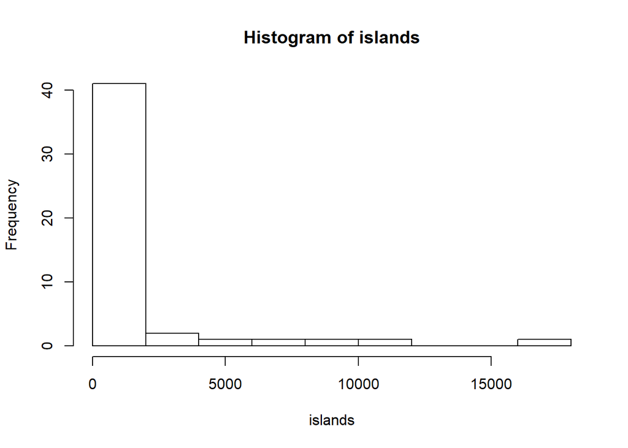

```r
hist(islands)
```

Barplot (`barplot`: bar plots)

Ejemplo:

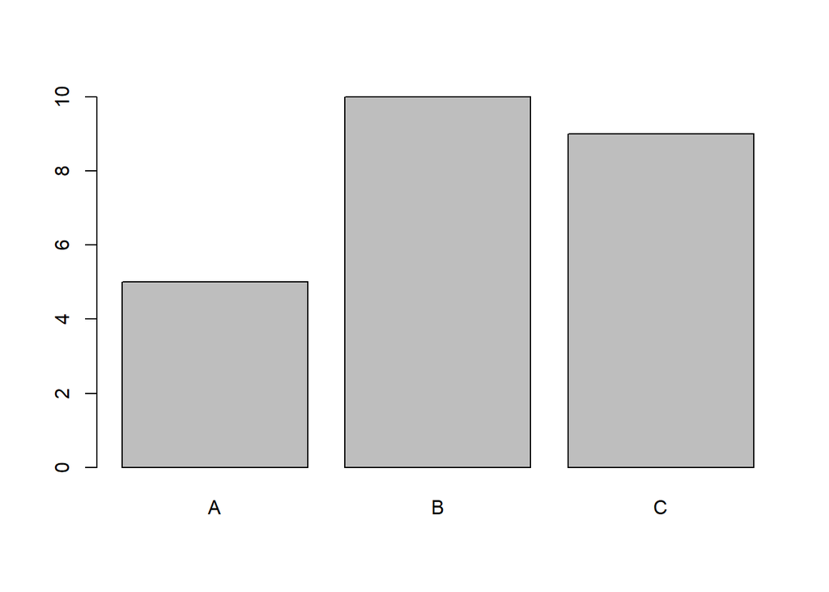

```r
DNAcon<-data.frame(muestra=c("A", "B", "C"), concentracionADN=c(5,10,9))
barplot(DNAcon$concentracionADN, names.arg=DNAcon$muestra)
```

***Definir colores

Los colores que R ocupa para colorear algo están definidos en `palette` y pueden cambiarse

```r
# Ver colores
palette()
```

```
## [1] "black"   "red"     "green3"  "blue"    "cyan"    "magenta" "yellow"
## [8] "gray"
```

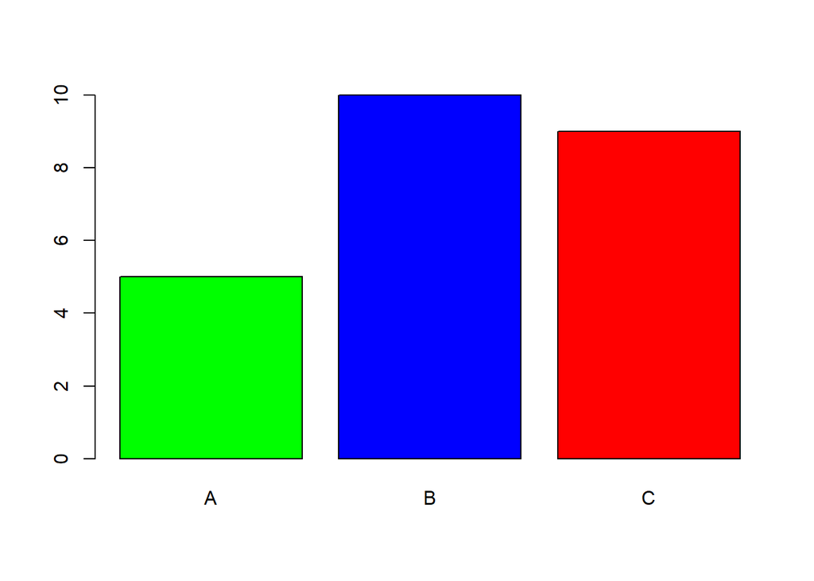

```r
# Cambiar colores
palette(c("green", "blue", "red"))
# volver a graficar
barplot(DNAcon$concentracionADN, names.arg=DNAcon$muestra,col=DNAcon$muestra)
```

Además de manualmente, los colores se pueden definir via paletas predeterminadas:

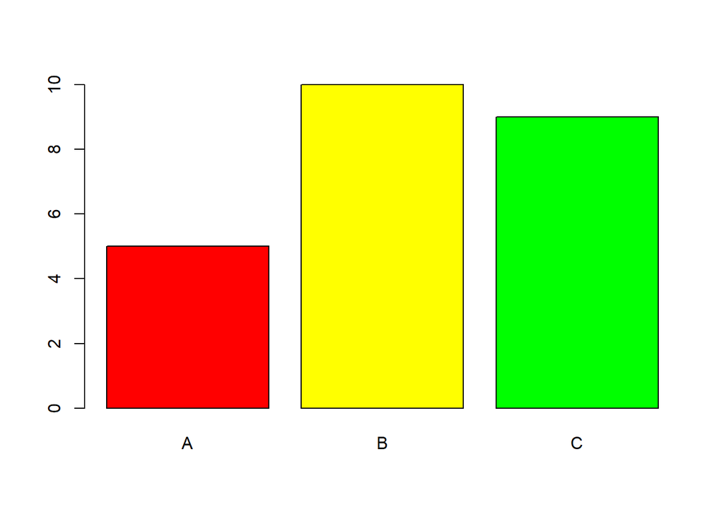

```r
# Cambiar palette a 6 colores del arcoiris
palette(rainbow(6))
# volver a graficar
barplot(DNAcon$concentracionADN, names.arg=DNAcon$muestra,col=DNAcon$muestra)
```

***Agregar una leyenda

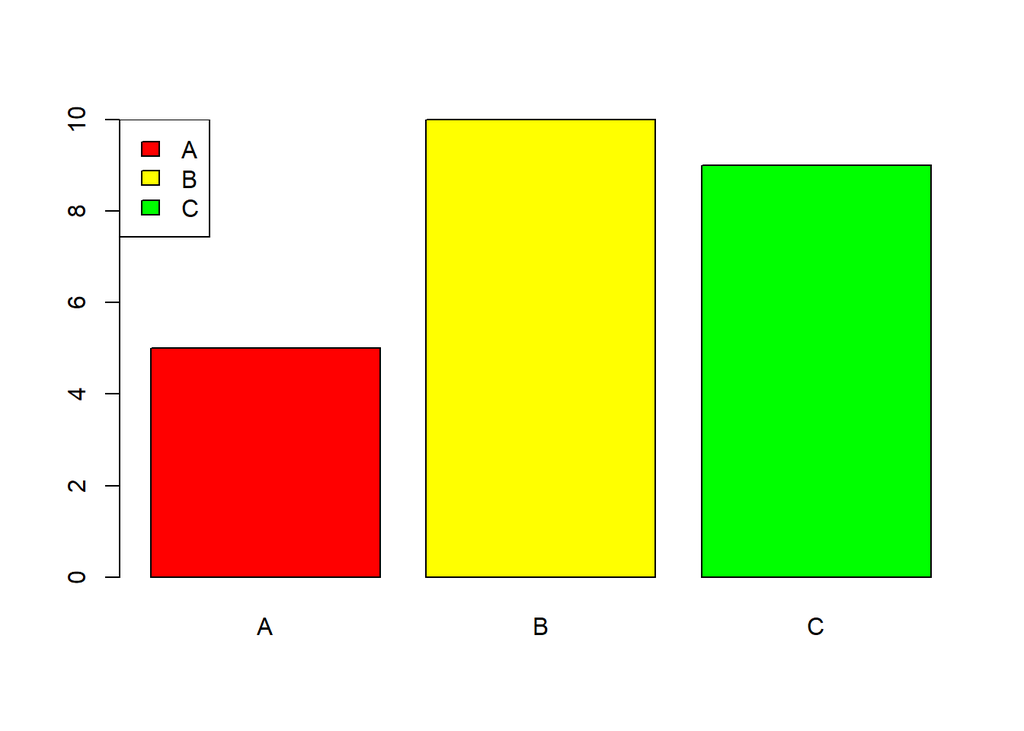

```r
# Graficar
barplot(DNAcon$concentracionADN, names.arg=DNAcon$muestra,col=DNAcon$muestra)
# Agregar leyenda
legend(x="topleft", legend=levels(DNAcon$muestra), fill=palette()[1:3])
```

Nota que `legend` es una función por si misma (i.e. NO un argumento de `plot`) que requiere que antes de correrlo se haya corrido `plot`. Es decir una vez que creamos una gráfica podemos **agregar sobre de esta** una leyenda. Lo mismo puede hacerse con la función `title`.

***ggplot2

Las gráficas que hemos visto hasta ahora pueden verse un poco feas de inicio y puede tomar un rato y mucho código arreglarlas a algo hermoso. `ggplot2` es un paquete que ahorra este trabajo y que ahora es ampliamente adoptado.

`ggplot2` construye gráficas “definiendo sus componentes paso a paso”.

Para poder usar `ggplot2` se requiere que la data.frame esté en **formato largo**. Además de esos apuntes puedes revisar [esto](http://www.cookbook-r.com/Manipulating_data/Converting_data_between_wide_and_long_format/) si te quedan dudas.